# Trade costs

Abstract

“Trade costs” published in R News.

## Introduction

Trade costs are the costs a trader must pay to implement a decision to buy or sell a security. Consider a single trade of a single equity security. Suppose on the evening of August 1, a trader decides to purchase 10,000 shares of IBM at $10, the *decision price* of the trade. The next day, the trader’s broker buys 10,000 shares in a rising market and pays $11 per share, the trade’s *execution price*.

How much did it cost to implement this trade? In the most basic ex-post analysis, trade costs are calculated by comparing the execution price of a trade to a benchmark price.[^1] Suppose we wished to compare the execution price to the price of the security at the time of the decision in the above example. Since the trader’s decision occurred at $10 and the broker paid $11, the cost of the trade relative to the decision price was $\$11 - \$10 = \$1$ per share, or $10,000 (9.1% of the total value of the execution).

Measuring costs relative to a trade’s decision price captures costs associated with the delay in the release of a trade into the market and movements in price after the decision was made but before the order is completed. It does not, however, provide a means to determine whether the broker’s execution reflects a fair price. For example, the price of $11 would be a poor price if most transactions in IBM on August 2 occurred at $10.50. For this purpose a better benchmark would be the day’s volume-weighted average price, or VWAP. If VWAP on August 2 was $10.50 and the trader used this as her benchmark, then the trade cost would be $0.50 per share, or $5,000.

The first version of the **tradeCosts** package provides a simple framework for calculating the cost of trades relative to a benchmark price, such as VWAP or decision price, over multiple periods along with basic reporting and plotting facilities to analyse these costs.

## Trade costs in a single period

Suppose we want to calculate trade costs for a single period. First, the data required to run the analysis must be assembled into three data frames.

The first data frame contains all trade-specific information, a sample of which is in the `trade.mar.2007` data frame:

```
> library("tradeCosts")
```

```
> data("trade.mar.2007")
> head(trade.mar.2007)
```

|  | period | id | side | exec.qty | exec.price |
| --- | --- | --- | --- | --- | --- |
| 1 | 2007-03-01 | 03818830 | X | 60600 | 1.60 |
| 2 | 2007-03-01 | 13959410 | B | 4400 | 32.21 |
| 3 | 2007-03-01 | 15976510 | X | 13600 | 7.19 |
| 4 | 2007-03-01 | 22122P10 | X | 119000 | 5.69 |
| 5 | 2007-03-01 | 25383010 | X | 9200 | 2.49 |
| 6 | 2007-03-01 | 32084110 | B | 3400 | 22.77 |

Trading data must include at least the set of columns included in the sample shown above: `period` is the (arbitrary) time interval during which the trade was executed, in this case a calendar trade day; `id` is a unique security identifier; `side` must be one of B (buy), S (sell), C (cover) or X (short sell); `exec.qty` is the number of shares executed; and `exec.price` is the price per share of the execution. The `create.trade.data` function can be used to create a data frame with all of the necessary information.

Second, trade cost analysis requires dynamic descriptive data, or data that changes across periods for each security.

```
> data("dynamic.mar.2007")
> head(dynamic.mar.2007[c("period", "id", "vwap",
+ "prior.close")])
```

|  | period | id | vwap | prior.close |
| --- | --- | --- | --- | --- |
| 1 | 2007-03-01 | 00797520 | 3.88 | 3.34 |
| 2 | 2007-03-01 | 010015 | 129.35 | 2.53 |
| 3 | 2007-03-01 | 023282 | 613.57 | 12.02 |
| 4 | 2007-03-01 | 03818830 | 1.58 | 1.62 |
| 5 | 2007-03-01 | 047628 | 285.67 | 5.61 |
| 6 | 2007-03-01 | 091139 | 418.48 | 8.22 |

The `period` and `id` columns match those in the trading data. The remaining two columns in the sample are benchmark prices: `vwap` is the volume-weighted average price for the period and `prior.close` is the security’s price at the end of the prior period.

The third data frame contains static data for each security.

```
> data("static.mar.2007")
> head(static.mar.2007)
```

|  | id | symbol | name | sector |
| --- | --- | --- | --- | --- |
| 1301 | 00036020 | AAON | Aaon Inc | IND |
| 2679 | 00036110 | AIR | Aar Corp | IND |
| 3862 | 00040010 | ABCB | Ameris Bancorp | FIN |
| 406 | 00080S10 | ABXA | Abx Air Inc | IND |
| 3239 | 00081T10 | ABD | Acco Brands Corp | IND |
| 325 | 00083310 | ACA | Aca Capital Hldgs Inc -redh | FIN |

The `id` column specifies an identifier that can be linked to the other data frames. Because this data is static, there is no `period` column.

Once assembled, these three data frames can be analysed by the `trade.costs` function:

```
> result <- trade.costs(trade = trade.mar.2007,
+   dynamic = dynamic.mar.2007,
+   static = static.mar.2007,
+   start.period = as.Date("2007-03-01"),
+   end.period = as.Date("2007-03-01"),
+   benchmark.price = "vwap")
```

The trade, dynamic, and static arguments refer to the three data frames discussed above. `start.period` and `end.period` specify the period range to analyse. This example analyses only one period, March 1, 2007, and uses the `vwap` column of the dynamic data frame as the benchmark price. `result` is an object of class `tradeCostsResults`.

```
> summary(result)
```

Trade Cost Analysis

Benchmark Price: vwap

```
Summary statistics:
  Total Market Value:      1,283,963
  First Period:           2007-03-01
  Last Period:            2007-03-01
  Total Cost:             -6,491
  Total Cost (bps):        -51
```

Best and worst batches over all periods:

|  | batch.name | exec.qty | cost |
| --- | --- | --- | --- |
| 1 | 22122P10 (2007-03-01 - 2007-03-01) | 119,000 | -3,572 |
| 2 | 03818830 (2007-03-01 - 2007-03-01) | 60,600 | -1,615 |
| 3 | 88362320 (2007-03-01 - 2007-03-01) | 31,400 | -1,235 |
| 6 | 25383010 (2007-03-01 - 2007-03-01) | 9,200 | 33 |
| 7 | 13959410 (2007-03-01 - 2007-03-01) | 4,400 | 221 |
| 8 | 32084110 (2007-03-01 - 2007-03-01) | 3,400 | 370 |

Best and worst securities over all periods:

|  | id | exec.qty | cost |
| --- | --- | --- | --- |
| 1 | 22122P10 | 119,000 | -3,572 |
| 2 | 03818830 | 60,600 | -1,615 |
| 3 | 88362320 | 31,400 | -1,235 |
| 6 | 25383010 | 9,200 | 33 |
| 7 | 13959410 | 4,400 | 221 |
| 8 | 32084110 | 3,400 | 370 |

NA report:

|  | count |
| --- | --- |
| id | 0 |
| period | 0 |
| side | 2 |
| exec.price | 0 |
| exec.qty | 0 |
| vwap | 1 |

The first section of the report provides high-level summary information. The total unsigned market value of trades for March 1 was around $1.3 million. Relative to VWAP, these trades cost -$6,491, indicating that overall the trades were executed at a level “better” than VWAP, where better buys/covers (sells/shorts) occur at prices below (above) VWAP. This total cost is the sum of the signed cost of each trade relative to the benchmark price. As a percentage of total executed market value, this set of trades cost -51 bps relative to VWAP.

The next section displays the best and worst *batches* over all periods. We will discuss batches in the next section. For now, note that when dealing with only one period, each trade falls into its own batch, so this section shows the most and least expensive trades for March 1. The next section displays the best and worst securities by total cost across all periods. Because there is only one trade per security on March 1, these results match the best and worst batches by cost.

Calculating the cost of a trade requires a non-NA value for `id`, `period`, `side`, `exec.price`, `exec.qty` and the benchmark price. The final section shows a count for each type of NA in the input data. Rows in the input data with NA’s in any of these columns are removed before the analysis is performed and reported here.

## Costs over multiple periods

Calculating trade costs over multiple periods works similarly. Cost can be calculated for each trade relative to a benchmark price which either varies over the period of the trade or is fixed at the decision price.

Suppose, for example, that the trader decided to short a stock on a particular day, but he wanted to trade so many shares that it took several days to complete the order. For instance, consider the following sequence of trades in our sample data set for Progressive Gaming, PGIC, which has id 59862K10:

```
> subset(trade.mar.2007, id %in% "59862K10")
```

|  | period | id | side | exec.qty | exec.price |
| --- | --- | --- | --- | --- | --- |
| 166 | 2007-03-13 | 59862K10 | X | 31700 | 5.77 |
| 184 | 2007-03-15 | 59862K10 | X | 45100 | 5.28 |
| 218 | 2007-03-19 | 59862K10 | X | 135800 | 5.05 |
| 259 | 2007-03-20 | 59862K10 | X | 22600 | 5.08 |

How should we calculate the cost of these trades? We could calculate the cost for each trade separately relative to a benchmark price such as `vwap`, exactly as in the last example. In this case, the cost of each trade in PGIC would be calculated relative to VWAP in each period and then added together. However, this method would ignore the cost associated with spreading out the sale over several days. If the price of the stock had been falling over the four days of the sale, for example, successive trades appear less attractive when compared to the price at the time of the decision. The trader can capture this cost by grouping the four short sales into a *batch* and comparing the execution price of each trade to the batch’s original decision price.

Performing this type of multi-period analysis using **tradeCosts** requires several modifications to the previous single period example. Note that since no period range is given, analysis is performed over the entire data set:

```
> result.batched <- trade.costs(trade.mar.2007,
+   dynamic = dynamic.mar.2007,
+   static = static.mar.2007,
+   batch.method = "same.sided",
+   benchmark.price = "decision.price")
```

First, `trade.costs` must be instructed how to group trades into batches by setting the `batch.method` parameter. This version of **tradeCosts** provides a single multi-period sample batch method, `same.sided`, which groups all consecutive same-sided orders into a single batch. Provided there were no buys in between the four sales in PGIC, all four trades would be grouped into the same batch. Second, setting `benchmark.price` to `decision.price` sets the benchmark price to the prior closing price of the first trade in the batch. Running summary on the new result yields the following:

```
> summary(result.batched)
```

## Trade Cost Analysis

Benchmark Price: `decision.price`

### Summary statistics:

| Total Market Value: | 47,928,402 |
| --- | --- |
| First Period: | 2007-03-01 |
| Last Period: | 2007-03-30 |
| Total Cost: | 587,148 |
| Total Cost (bps): | 123 |

### Best and worst batches over all periods:

|  | batch.name | exec.qty | cost |
| --- | --- | --- | --- |
| 1 | 04743910 (2007-03-19 - 2007-03-19) | 17,800 | -82,491 |
| 2 | 31659U30 (2007-03-09 - 2007-03-13) | 39,800 | -33,910 |
| 3 | 45885A30 (2007-03-13 - 2007-03-19) | 152,933 | -31,904 |
| 274 | 49330810 (2007-03-13 - 2007-03-30) | 83,533 | 56,598 |
| 275 | 15649210 (2007-03-15 - 2007-03-28) | 96,900 | 71,805 |
| 276 | 59862K10 (2007-03-13 - 2007-03-20) | 235,200 | 182,707 |

### Best and worst securities over all periods:

|  | id | exec.qty | cost |
| --- | --- | --- | --- |
| 1 | 04743910 | 17,800 | -82,491 |
| 2 | 31659U30 | 51,400 | -32,616 |
| 3 | 45885A30 | 152,933 | -31,904 |
| 251 | 49330810 | 83,533 | 56,598 |
| 252 | 15649210 | 118,100 | 73,559 |
| 253 | 59862K10 | 235,200 | 182,707 |

### NA report:

|  | count |
| --- | --- |
| id | 0 |
| period | 0 |
| side | 6 |
| exec.price | 0 |
| exec.qty | 0 |
| prior.close | 2 |

This analysis covers almost $50 million of executions from March 1 to March 30, 2007. Relative to decision price, the trades cost $587,148, or 1.23% of the total executed market value.

The most expensive batch in the result contained the four sells in PGIC (59862K10) from March 13 to March 20, which cost $182,707.

### Plotting results

The **tradeCosts** package includes a `plot` method that displays bar charts of trade costs. It requires two arguments, a `tradeCostsResults` object, and a character string that describes the type of plot to create.

The simplest plot is a time series of total trade costs in basis points over each period:

```
> plot(result.batched, "time.series.bps")
```

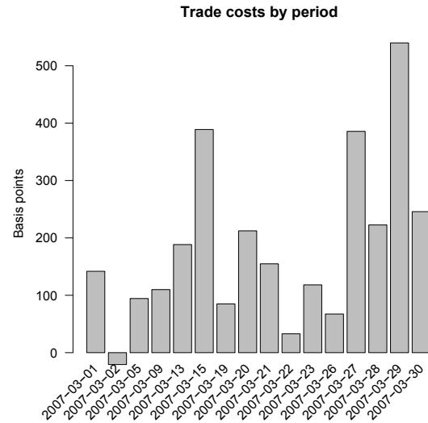

Figure 1: A time series plot of trade costs.

This chart displays the cost for each day in the previous example. According to this chart, all days had positive cost except March 2.

The second plot displays trade costs divided into categories defined by a column in the static data frame passed to `trade.costs`. Since sector was a column of that data frame, we can look at costs by company sector:

```
> plot(result.batched, "sector")
```

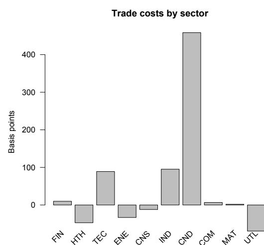

Figure 2: A plot of trade costs by sector.

Over the period of the analysis, trades in CND were especially expensive relative to decision price.

```
> plot(result.batched, "cumulative")
```

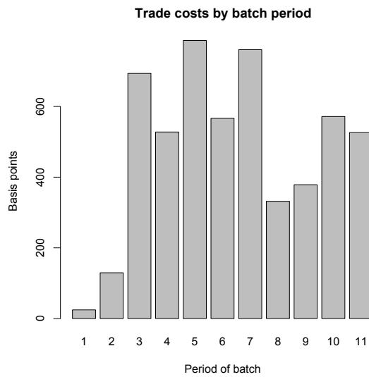

Figure 3: Costs by batch period, in bps.

As one might expect, the first and second trades in a batch are the cheapest with respect to decision price because they occur closest to the time of the decision.

## Conclusion

**tradeCosts** currently provides a simple means of calculating the cost of trades relative to a benchmark price over multiple periods. Costs may be calculated relative to a period-specific benchmark price or, for trades spanning multiple periods, the initial decision price of the trade. We hope that over time and through collaboration the package will be able to tackle more complex issues, such as ex-ante modeling and finer compartmentalization of trade costs.

## References

R. Kissell and M. Glantz. *Optimal Trading Strategies*. American Management Association, 2003.

[^1]: For an in-depth discussion of both ex-ante modeling and ex-post measurement of trade costs, see Kissell and Glantz (2003).